# Question

In Adams, Massachusetts, 4 candidates (W through Z) are running in an election with a single winner. There are 7 voters (A through G) who each rank the candidates from 1 to 4, with 1 meaning first choice and 4 meaning last choice. Those rankings are shown below. Each column represents a single voter’s ranking.

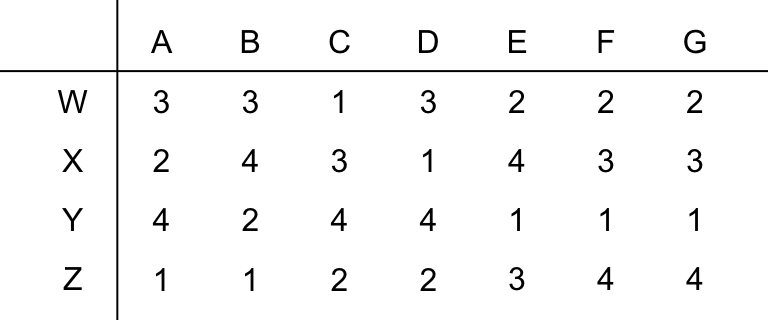

What [Borda count](https://en.wikipedia.org/wiki/Borda_count) would each candidate get?

- Borda count of candidate W: ##ANSWER1##
- Borda count of candidate X: ##ANSWER2##
- Borda count of candidate Y: ##ANSWER3##
- Borda count of candidate Z: ##ANSWER4##
- Who wins the Borda election? ##ANSWER5##

## Answerlist

- 4
- 6
- 7
- 8
- 9
- 10
- 11
- 12
- 13
- 14
- 4
- 6
- 7
- 8
- 9
- 10
- 11
- 12
- 13
- 14
- 4
- 6
- 7
- 8
- 9
- 10
- 11
- 12
- 13
- 14
- 4
- 6
- 7
- 8
- 9
- 10
- 11
- 12
- 13
- 14
- Candidate W
- Candidate X
- Candidate Y
- Candidate Z

# Solution

There are 4 candidates. So, we subtract each preference number from 4 to get Borda points. We then add all the Borda points from each voter.

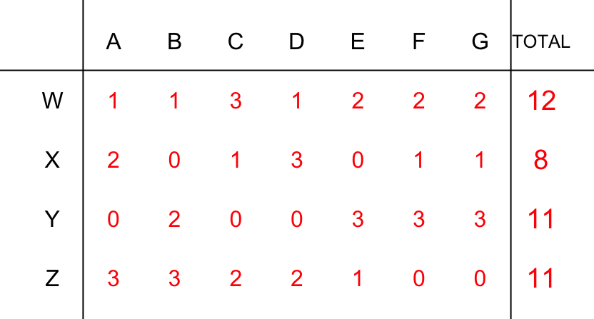

# Meta-information

extype: cloze exclozetype: schoice|schoice|schoice|schoice|schoice exsolution: 0000000100|0001000000|0000001000|0000001000|1000 exname: borda